# W3cubDocs

/Qt 6.9

# Qt Widgets

The [Qt Widgets Module](https://doc.qt.io/qt-6.9/qtwidgets-module.html) provides a set of UI elements to create classic desktop-style user interfaces. See the [User Interfaces](https://doc.qt.io/qt-6.9/topics-ui.html) overview for more information on using widgets.

## Widgets

Widgets are the primary elements for creating user interfaces in Qt. Widgets can display data and status information, receive user input, and provide a container for other widgets that should be grouped together. A widget that is not embedded in a parent widget is called a window.

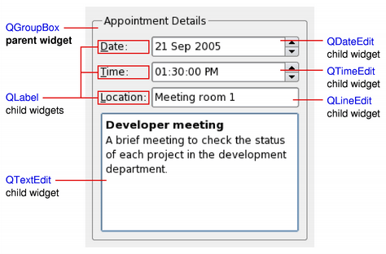

The QWidget class provides the basic capability to render to the screen and to handle user input events. All UI elements that Qt provides are either subclasses of QWidget or are used in connection with a QWidget subclass. To create custom widgets, subclass QWidget or a suitable subclass and reimplement the virtual event handlers.

- Window and Dialog Widgets
- Application Main Window
- Dialog Windows
- Keyboard Focus in Widgets

## Styles

Styles draw on behalf of widgets and encapsulate the look and feel of a GUI. Qt's built-in widgets use the QStyle class to perform nearly all of their drawing, ensuring that they look exactly like the equivalent native widgets.

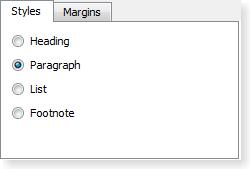

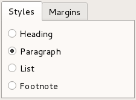

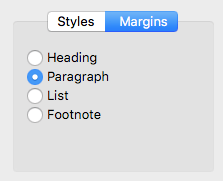

Qt Style Sheets are a powerful mechanism that lets you customize the appearance of widgets, in addition to what is already possible by subclassing QStyle.

## Layouts

Layouts are an elegant and flexible way to automatically arrange child widgets within their container. Each widget reports its size requirements to the layout through the sizeHint and sizePolicy properties, and the layout distributes the available space accordingly.

Qt Widgets Designer is a powerful tool for interactively creating and arranging widgets in layouts.

## Model/View Classes

The model/view architecture provides classes that manage the way data is presented to the user. Data-driven applications which use lists and tables are structured to separate the data and view using models, views, and delegates.

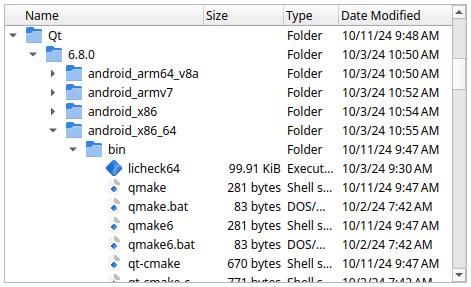

## Graphics View

The Graphics View Framework is for managing and interacting with a large number of custom-made 2D graphical items, and a view widget for visualizing the items, with support for zooming and rotation.

[figure not shown]

## Using the Module

Using a Qt module's C++ API requires linking against the module library, either directly or through other dependencies. Several build tools have dedicated support for this, including [CMake](https://cmake.org/cmake/help/latest/) and [qmake](https://doc.qt.io/qt-6.9/qmake-manual.html).

### Building with CMake

Use the `find_package()` command to locate the needed module component in the `Qt6` package:

```
find_package(Qt6 REQUIRED COMPONENTS Widgets)
target_link_libraries(mytarget PRIVATE Qt6::Widgets)
```

For more details, see the Build with CMake overview.

### Building with qmake

To configure the module for building with qmake, add the module as a value of the `QT` variable in the project's .pro file:

```
QT += widgets
```

## Articles and Guides

- [Widgets Tutorial](https://doc.qt.io/qt-6.9/widgets-tutorial.html)
- Getting Started Programming with Qt Widgets
- [Qt Creator: Tutorial: Qt Widgets application](https://doc.qt.io/qtcreator/creator-writing-program.html)
- [Model/View Tutorial](https://doc.qt.io/qt-6.9/modelview.html)

## Examples

- [Qt Widgets Examples](https://doc.qt.io/qt-6.9/examples-widgets.html)
- Layout Examples
- [Tools Examples](https://doc.qt.io/qt-6.9/examples-widgets-tools.html)

## API Reference

- [Qt Widgets C++ Classes](https://doc.qt.io/qt-6.9/qtwidgets-module.html)
  - Basic Widget Classes
  - Advanced Widget Classes
  - Abstract Widget Classes
  - Organizer Widget Classes
  - Graphics View Classes
  - Model/View Classes
  - Main Window and Related Classes
  - Widget Appearance and Style Related Classes
  - Layout Classes
- Qt Style Sheets Reference

## Module Evolution

Changes to Qt Widgets lists important changes in the module API and functionality that were done for the Qt 6 series of Qt.

## Licenses

The Qt Widgets module is available under commercial licenses from [The Qt Company](http://www.qt.io/about-us/). In addition, it is available under free software licenses: The [GNU Lesser General Public License, version 3](http://www.gnu.org/licenses/lgpl-3.0.html), or the [GNU General Public License, version 2](http://www.gnu.org/licenses/gpl-2.0.html). See [Qt Licensing](https://doc.qt.io/qt-6.9/licensing.html) for further details.

© The Qt Company Ltd  
Licensed under the GNU Free Documentation License, Version 1.3.  
https://doc.qt.io/qt-6.9/qtwidgets-index.html